# PA D208 TASK1 MLR BY KOFFI M. GANU

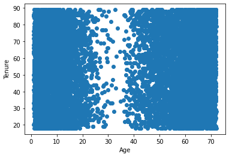

```python
plt.scatter(df.Tenure, df.Age)
plt.xlabel("Age")
plt.ylabel("Tenure")
plt.show()
```

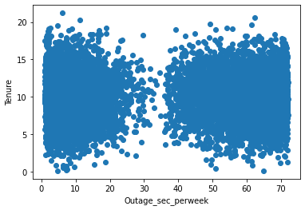

```python
plt.scatter(df.Tenure, df.Outage_sec_perweek)
plt.xlabel("Outage_sec_perweek")
plt.ylabel("Tenure")
plt.show()
```

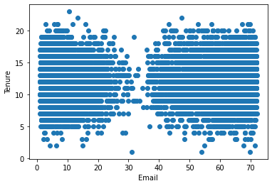

```python
plt.scatter(df.Tenure, df.Email)
plt.xlabel("Email")
plt.ylabel("Tenure")
plt.show()
```

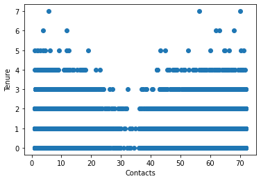

```python
plt.scatter(df.Tenure, df.Contacts)
plt.xlabel("Contacts")
plt.ylabel("Tenure")
plt.show()
```

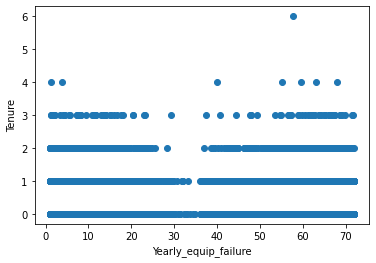

```python
plt.scatter(df.Tenure, df.Yearly_equip_failure)
plt.xlabel("Yearly_equip_failure")
plt.ylabel("Tenure")
plt.show()
```

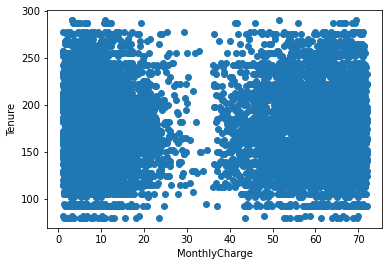

```python
plt.scatter(df.Tenure, df.MonthlyCharge)
plt.xlabel("MonthlyCharge")
plt.ylabel("Tenure")
plt.show()
```

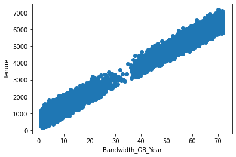

```python
plt.scatter(df.Tenure, df.Bandwidth_GB_Year)
plt.xlabel("Bandwidth_GB_Year")
plt.ylabel("Tenure")
plt.show()
```

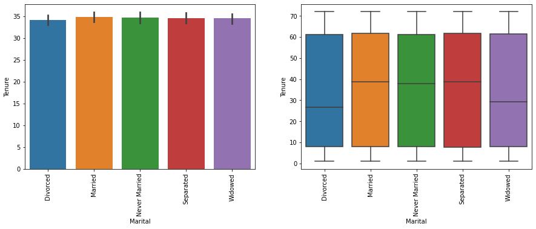

```python
plt.figure(figsize=(15, 5))

plt.subplot(1, 2, 1)
sns.barplot(data=df, y="Tenure", x="Marital")
plt.xticks(rotation=90)

plt.subplot(1, 2, 2)
sns.boxplot(data=df, y="Tenure", x="Marital")
plt.xticks(rotation=90)

plt.show()
```

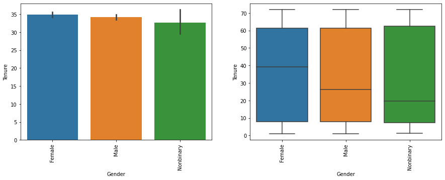

```python
plt.figure(figsize=(15, 5))

plt.subplot(1, 2, 1)
sns.barplot(data=df, y="Tenure", x="Gender")
plt.xticks(rotation=90)

plt.subplot(1, 2, 2)
sns.boxplot(data=df, y="Tenure", x="Gender")
plt.xticks(rotation=90)

plt.show()
```

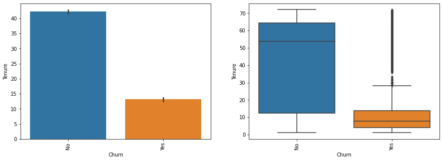

```python
plt.figure(figsize=(15, 5))

plt.subplot(1, 2, 1)
sns.barplot(data=df, y="Tenure", x="Churn")
plt.xticks(rotation=90)

plt.subplot(1, 2, 2)
sns.boxplot(data=df, y="Tenure", x="Churn")
plt.xticks(rotation=90)

plt.show()
```

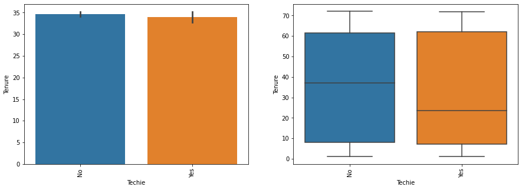

```python
plt.figure(figsize=(15, 5))

plt.subplot(1, 2, 1)
sns.barplot(data=df, y="Tenure", x="Techie")
plt.xticks(rotation=90)

plt.subplot(1, 2, 2)
sns.boxplot(data=df, y="Tenure", x="Techie")
plt.xticks(rotation=90)

plt.show()
```

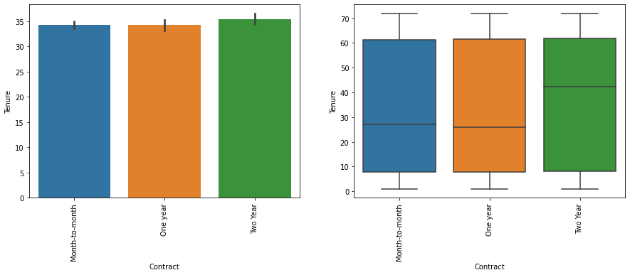

```python
plt.figure(figsize=(15, 5))

plt.subplot(1, 2, 1)
sns.barplot(data=df, y="Tenure", x="Contract")
plt.xticks(rotation=90)

plt.subplot(1, 2, 2)
sns.boxplot(data=df, y="Tenure", x="Contract")
plt.xticks(rotation=90)

plt.show()
```

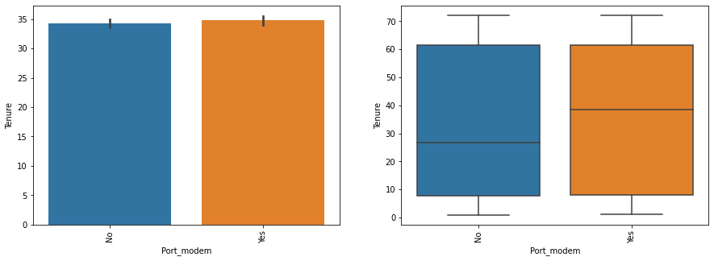

```python
plt.figure(figsize=(15, 5))

plt.subplot(1, 2, 1)
sns.barplot(data=df, y="Tenure", x="Port_modem")
plt.xticks(rotation=90)

plt.subplot(1, 2, 2)
sns.boxplot(data=df, y="Tenure", x="Port_modem")
plt.xticks(rotation=90)

plt.show()
```

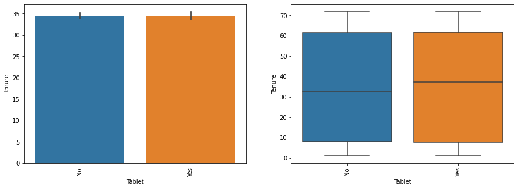

```python
plt.figure(figsize=(15, 5))

plt.subplot(1, 2, 1)
sns.barplot(data=df, y="Tenure", x="Tablet")
plt.xticks(rotation=90)

plt.subplot(1, 2, 2)
sns.boxplot(data=df, y="Tenure", x="Tablet")
plt.xticks(rotation=90)

plt.show()
```

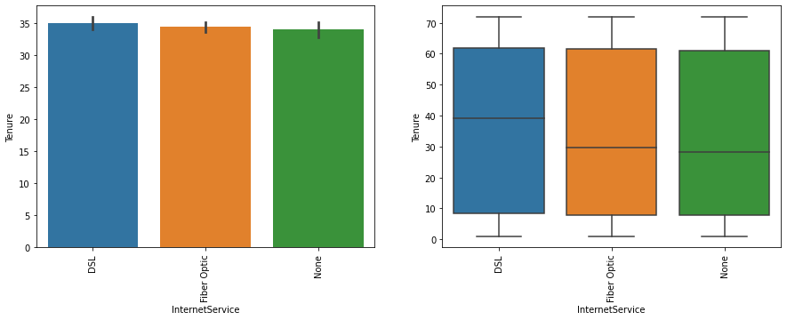

```python
plt.figure(figsize=(15, 5))

plt.subplot(1, 2, 1)
sns.barplot(data=df, y="Tenure", x="InternetService")
plt.xticks(rotation=90)

plt.subplot(1, 2, 2)
sns.boxplot(data=df, y="Tenure", x="InternetService")
plt.xticks(rotation=90)

plt.show()
```

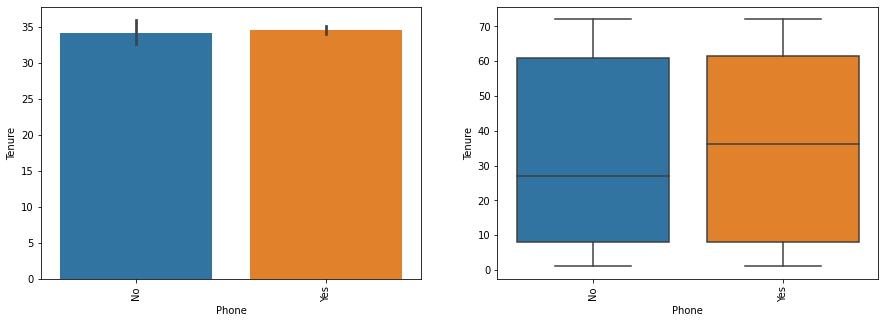

```python
plt.figure(figsize=(15, 5))

plt.subplot(1, 2, 1)
sns.barplot(data=df, y="Tenure", x="Phone")
plt.xticks(rotation=90)

plt.subplot(1, 2, 2)
sns.boxplot(data=df, y="Tenure", x="Phone")
plt.xticks(rotation=90)

plt.show()
```

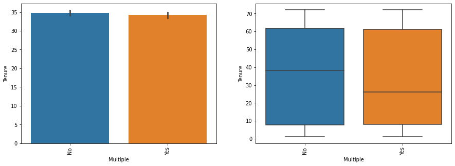

```python
plt.figure(figsize=(15, 5))

plt.subplot(1, 2, 1)
sns.barplot(data=df, y="Tenure", x="Multiple")
plt.xticks(rotation=90)

plt.subplot(1, 2, 2)
sns.boxplot(data=df, y="Tenure", x="Multiple")
plt.xticks(rotation=90)

plt.show()
```

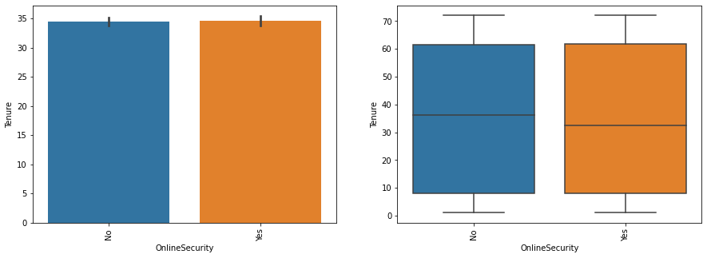

```python
plt.figure(figsize=(15, 5))

plt.subplot(1, 2, 1)
sns.barplot(data=df, y="Tenure", x="OnlineSecurity")
plt.xticks(rotation=90)

plt.subplot(1, 2, 2)
sns.boxplot(data=df, y="Tenure", x="OnlineSecurity")
plt.xticks(rotation=90)

plt.show()
```

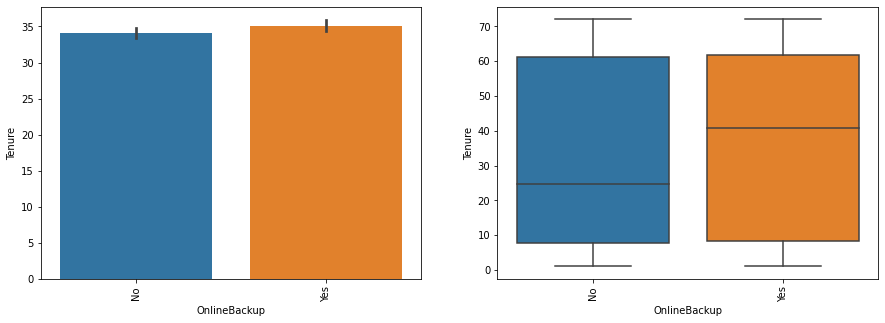

```python
plt.figure(figsize=(15, 5))

plt.subplot(1, 2, 1)
sns.barplot(data=df, y="Tenure", x="OnlineBackup")
plt.xticks(rotation=90)

plt.subplot(1, 2, 2)
sns.boxplot(data=df, y="Tenure", x="OnlineBackup")
plt.xticks(rotation=90)

plt.show()
```

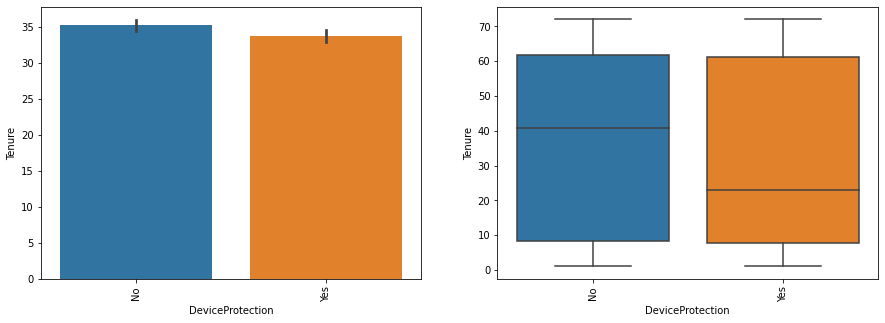

```python
plt.figure(figsize=(15, 5))

plt.subplot(1, 2, 1)
sns.barplot(data=df, y="Tenure", x="DeviceProtection")
plt.xticks(rotation=90)

plt.subplot(1, 2, 2)
sns.boxplot(data=df, y="Tenure", x="DeviceProtection")
plt.xticks(rotation=90)

plt.show()
```

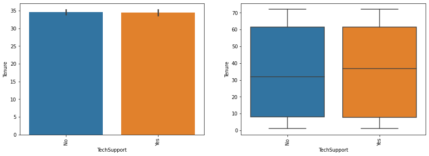

```python
plt.figure(figsize=(15, 5))

plt.subplot(1, 2, 1)
sns.barplot(data=df, y="Tenure", x="TechSupport")
plt.xticks(rotation=90)

plt.subplot(1, 2, 2)
sns.boxplot(data=df, y="Tenure", x="TechSupport")
plt.xticks(rotation=90)

plt.show()
```

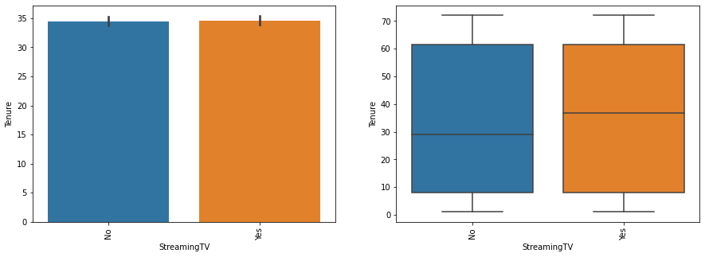

```python
plt.figure(figsize=(15, 5))

plt.subplot(1, 2, 1)
sns.barplot(data=df, y="Tenure", x="StreamingTV")
plt.xticks(rotation=90)

plt.subplot(1, 2, 2)
sns.boxplot(data=df, y="Tenure", x="StreamingTV")
plt.xticks(rotation=90)

plt.show()
```

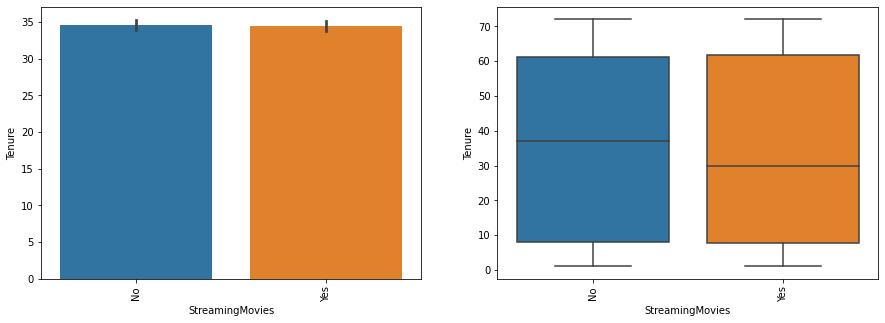

```python
plt.figure(figsize=(15, 5))

plt.subplot(1, 2, 1)
sns.barplot(data=df, y="Tenure", x="StreamingMovies")
plt.xticks(rotation=90)

plt.subplot(1, 2, 2)
sns.boxplot(data=df, y="Tenure", x="StreamingMovies")
plt.xticks(rotation=90)

plt.show()
```

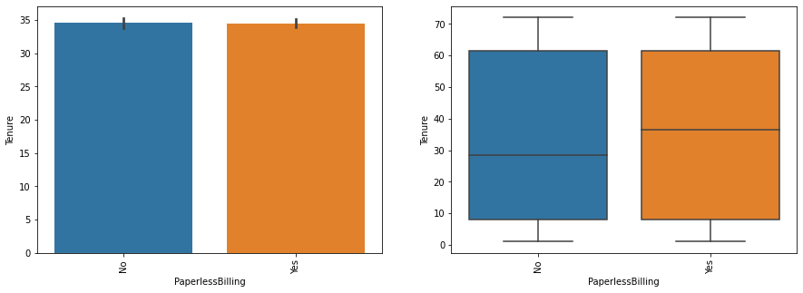

```python
plt.figure(figsize=(15, 5))

plt.subplot(1, 2, 1)
sns.barplot(data=df, y="Tenure", x="PaperlessBilling")
plt.xticks(rotation=90)

plt.subplot(1, 2, 2)
sns.boxplot(data=df, y="Tenure", x="PaperlessBilling")
plt.xticks(rotation=90)

plt.show()
```

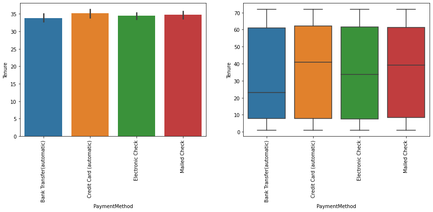

```python
plt.figure(figsize=(15, 5))

plt.subplot(1, 2, 1)
sns.barplot(data=df, y="Tenure", x="PaymentMethod")
plt.xticks(rotation=90)

plt.subplot(1, 2, 2)
sns.boxplot(data=df, y="Tenure", x="PaymentMethod")
plt.xticks(rotation=90)

plt.show()
```

```python
# Discover missing data points within dataset
df = df.isnull().sum()
print(df)
```

```
Population              0
Job                     0
Children                0
Age                     0
Income                  0
Marital                 0
Gender                  0
Churn                   0
Outage_sec_perweek      0
Email                   0
Contacts                0
Yearly_equip_failure    0
Techie                  0
Contract                0
Port_modem              0
Tablet                  0
InternetService         0
Phone                   0
Multiple                0
OnlineSecurity          0
OnlineBackup            0
DeviceProtection        0
TechSupport             0
StreamingTV             0
StreamingMovies         0
PaperlessBilling        0
PaymentMethod           0
Tenure                  0
MonthlyCharge           0
Bandwidth_GB_Year       0
TimelyResponse          0
Fixes                   0
Replacements            0
Reliability             0
Options                 0
Respectfulness          0
Courteous               0
Listening               0
dtype: int64
```

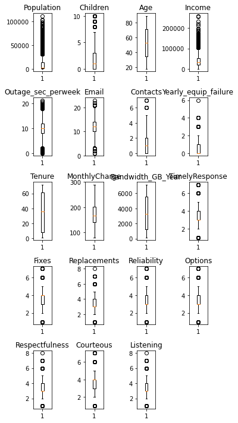

```python
numeric_columns = df.select_dtypes(include=np.number).columns.tolist()
plt.figure(figsize=(5, 10))

for i, variable in enumerate(numeric_columns):
    plt.subplot(5, 4, i + 1)
    plt.boxplot(df[variable], whis=1.5)
    plt.tight_layout()
    plt.title(variable)

plt.show()
```

```python
def treat_outliers(df, col):
    """
    treats outliers in a variable
    col: str, name of the numerical variable
    df: dataframe
    col: name of the column
    """
    Q1 = df[col].quantile(0.25)  # 25th quantile
    Q3 = df[col].quantile(0.75)  # 75th quantile
    IQR = Q3 - Q1
    Lower_Whisker = Q1 - 1.5 * IQR
    Upper_Whisker = Q3 + 1.5 * IQR

    # all the values smaller than Lower_Whisker will be assigned the value of Lower_Whisker
    # all the values greater than Upper_Whisker will be assigned the value of Upper_Whisker
    df[col] = np.clip(df[col], Lower_Whisker, Upper_Whisker)

    return df


def treat_outliers_all(df, col_list):
    """
    treat outlier in all numerical variables
    col_list: list of numerical variables
    df: data frame
    """
    for c in col_list:
        df = treat_outliers(df, c)

    return df
```

```python
numerical_col = df.select_dtypes(include=np.number).columns.tolist()
df = treat_outliers_all(df, numerical_col)
```

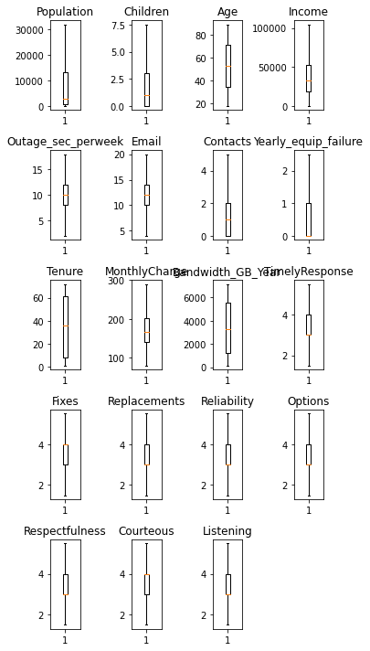

```python
numeric_columns = df.select_dtypes(include=np.number).columns.tolist()
plt.figure(figsize=(5, 10))

for i, variable in enumerate(numeric_columns):
    plt.subplot(5, 4, i + 1)
    plt.boxplot(df[variable], whis=1.5)
    plt.tight_layout()
    plt.title(variable)

plt.show()
```

```python
df = df.drop(columns=['Population', 'Job', 'Marital', 'PaymentMethod'])
```

```python
print(df)
```

```
      Children  Age    Income  Gender Churn  Outage_sec_perweek  Email  \
0          0.0   68  28561.99    Male    No            7.978323     10
1          1.0   27  21704.77  Female   Yes           11.699080     12
2          4.0   50   9609.57  Female    No           10.752800      9
3          1.0   48  18925.23    Male    No           14.913540     15
4          0.0   83  40074.19    Male   Yes            8.147417     16
...        ...  ...       ...     ...   ...                 ...    ...
9995       3.0   23  55723.74    Male    No            9.415935     12
9996       4.0   48  34129.34    Male    No            6.740547     15
9997       1.0   48  45983.43  Female    No            6.590911     10
9998       1.0   39  16667.58    Male    No           12.071910     14
9999       1.0   28   9020.92    Male    No           11.754720     17

      Contacts  Yearly_equip_failure Techie  ... MonthlyCharge  \
0            0                   1.0     No  ...    172.455519
```

[output cut: 38 more lines]

```python
# defining X and y variables
X = df.drop(["Tenure"], axis=1)
Y = df["Tenure"]
```

```python
X = pd.get_dummies(
    X,
    columns=X.select_dtypes(include=["object", "category"]).columns.tolist(),
    drop_first=True,
)
X.head()
```

|  | Children | Age | Income | Outage_sec_perweek | Email | Contacts | Yearly_equip_failure | MonthlyCharge | Bandwidth_GB_Year | TimelyResponse | ... | InternetService_None | Phone_Yes | Multiple_Yes | OnlineSecurity_Yes | OnlineBackup_Yes | DeviceProtection_Yes | TechSupport_Yes | StreamingTV_Yes | StreamingMovies_Yes | PaperlessBilling_Yes |
| --- | --- | --- | --- | --- | --- | --- | --- | --- | --- | --- | --- | --- | --- | --- | --- | --- | --- | --- | --- | --- | --- |
| 0 | 0.0 | 68 | 28561.99 | 7.978323 | 10 | 0 | 1.0 | 172.455519 | 904.536110 | 5.0 | ... | 0 | 1 | 0 | 1 | 1 | 0 | 0 | 0 | 1 | 1 |
| 1 | 1.0 | 27 | 21704.77 | 11.699080 | 12 | 0 | 1.0 | 242.632554 | 800.982766 | 3.0 | ... | 0 | 1 | 1 | 1 | 0 | 0 | 0 | 1 | 1 | 1 |
| 2 | 4.0 | 50 | 9609.57 | 10.752800 | 9 | 0 | 1.0 | 159.947583 | 2054.706961 | 4.0 | ... | 0 | 1 | 1 | 0 | 0 | 0 | 0 | 0 | 1 | 1 |
| 3 | 1.0 | 48 | 18925.23 | 14.913540 | 15 | 2 | 0.0 | 119.956840 | 2164.579412 | 4.0 | ... | 0 | 1 | 0 | 1 | 0 | 0 | 0 | 1 | 0 | 1 |
| 4 | 0.0 | 83 | 40074.19 | 8.147417 | 16 | 2 | 1.0 | 149.948316 | 271.493436 | 4.0 | ... | 0 | 0 | 0 | 0 | 0 | 0 | 1 | 1 | 0 | 0 |

5 rows × 36 columns

```python
# splitting the data in 70:30 ratio for train to test data

x_train, x_test, y_train, y_test = train_test_split(
    X, Y, test_size=0.3, random_state=42
)
```

```python
print("Number of rows in train data =", x_train.shape[0])
print("Number of rows in test data =", x_test.shape[0])
```

```
Number of rows in train data = 7000
Number of rows in test data = 3000
```

```python
# we have to add the constant manually
x_train1 = sm.add_constant(x_train)
# adding constant to the test data
x_test1 = sm.add_constant(x_test)
```

```python
olsmod0 = sm.OLS(y_train, x_train1).fit()
print(olsmod0.summary())
```

```
                            OLS Regression Results
==============================================================================
Dep. Variable:                 Tenure   R-squared:                       1.000
Model:                            OLS   Adj. R-squared:                  1.000
Method:                 Least Squares   F-statistic:                 6.558e+06
Date:                Sun, 12 Feb 2023   Prob (F-statistic):               0.00
Time:                        16:40:25   Log-Likelihood:                 3647.4
No. Observations:                7000   AIC:                            -7221.
Df Residuals:                    6963   BIC:                            -6967.
Df Model:                          36
Covariance Type:            nonrobust
===============================================================================================
                                  coef    std err          t      P>|t|      [0.025      0.975]
-----------------------------------------------------------------------------------------------
const                          -3.7931      0.027   -142.431      0.000      -3.845      -3.741
Children                       -0.4011      0.001   -460.223      0.000      -0.403      -0.399
Age                             0.0400   8.35e-05    479.404      0.000       0.040       0.040
Income                      -3.525e-08   6.75e-08     -0.523      0.601   -1.67e-07     9.7e-08
Outage_sec_perweek              0.0010      0.001      1.694      0.090      -0.000       0.002
Email                          -0.0002      0.001     -0.351      0.726      -0.001       0.001
Contacts                        0.0004      0.002      0.250      0.802      -0.003       0.004
Yearly_equip_failure           -0.0005      0.003     -0.167      0.867      -0.006       0.005
MonthlyCharge                  -0.0353      0.000   -178.037      0.000      -0.036      -0.035
Bandwidth_GB_Year               0.0122   9.55e-07   1.28e+04      0.000       0.012       0.012
TimelyResponse                  0.0008      0.003      0.291      0.771      -0.004       0.006
Fixes                           0.0007      0.002      0.274      0.784      -0.004       0.005
Replacements                    0.0008      0.002      0.360      0.719      -0.004       0.005
Reliability                    -0.0002      0.002     -0.122      0.903      -0.004       0.004
Options                        -0.0019      0.002     -0.939      0.348      -0.006       0.002
Respectfulness                 -0.0032      0.002     -1.495      0.135      -0.007       0.001
Courteous                      -0.0033      0.002     -1.636      0.102      -0.007       0.001
Listening                       0.0012      0.002      0.645      0.519      -0.003       0.005
Gender_Male                    -0.7944      0.003   -227.251      0.000      -0.801      -0.788
Gender_Nonbinary                0.2729      0.012     22.669      0.000       0.249       0.297
Churn_Yes                       0.0084      0.006      1.532      0.125      -0.002       0.019
Techie_Yes                     -0.0027      0.005     -0.578      0.563      -0.012       0.006
Contract_One year               0.0024      0.005      0.531      0.596      -0.007       0.011
Contract_Two Year               0.0022      0.004      0.491      0.623      -0.006       0.011
Port_modem_Yes                  0.0036      0.003      1.028      0.304      -0.003       0.010
Tablet_Yes                      0.0024      0.004      0.627      0.531      -0.005       0.010
InternetService_Fiber Optic     5.7521      0.006   1010.720      0.000       5.741       5.763
InternetService_None            4.5981      0.005    853.783      0.000       4.588       4.609
Phone_Yes                       0.0002      0.006      0.034      0.973      -0.012       0.012
Multiple_Yes                    0.2714      0.007     37.294      0.000       0.257       0.286
OnlineSecurity_Yes             -0.8320      0.004   -228.221      0.000      -0.839      -0.825
OnlineBackup_Yes               -0.3467      0.006    -61.593      0.000      -0.358      -0.336
DeviceProtection_Yes           -0.5952      0.004   -139.650      0.000      -0.604      -0.587
TechSupport_Yes                 0.3850      0.004     88.715      0.000       0.376       0.393
StreamingTV_Yes                -1.3003      0.009   -145.191      0.000      -1.318      -1.283
StreamingMovies_Yes            -0.7152      0.011    -65.950      0.000      -0.736      -0.694
PaperlessBilling_Yes            0.0002      0.004      0.045      0.964      -0.007       0.007
==============================================================================
Omnibus:                     2669.222   Durbin-Watson:                   1.999
Prob(Omnibus):                  0.000   Jarque-Bera (JB):            18965.286
Skew:                          -1.653   Prob(JB):                         0.00
Kurtosis:                      10.355   Cond. No.                     7.82e+05
==============================================================================

Notes:
[1] Standard Errors assume that the covariance matrix of the errors is correctly specified.
[2] The condition number is large, 7.82e+05. This might indicate that there are
strong multicollinearity or other numerical problems.
```

Observations

Both the R-squared and Adjusted R squared of our model are 1.00, indicating that it can explain 100% of the variance in the tenure.

This is a clear indication that we have been able to create a very good model which is not underfitting the data.

To be able to make statistical inferences from our model, we will have to test that the linear regression assumptions are followed.

Let's check the model performance.

```python
# function to compute MAPE
def mape_score(targets, predictions):
    return np.mean(np.abs(targets - predictions) / targets) * 100


# function to compute different metrics to check performance of a regression model
def model_performance_regression(model, predictors, target):
    """
    Function to compute different metrics to check regression model performance

    model: regressor
    predictors: independent variables
    target: dependent variable
    """

    # predicting using the independent variables
    pred = model.predict(predictors)

    # computing the actual prices by using the exponential function
    target = np.exp(target)
    pred = np.exp(pred)

    rmse = np.sqrt(mean_squared_error(target, pred))  # to compute RMSE
    mae = mean_absolute_error(target, pred)  # to compute MAE
    mape = mape_score(target, pred)  # to compute MAPE

    # creating a dataframe of metrics
    df_perf = pd.DataFrame(
        {
            "RMSE": rmse,
            "MAE": mae,
            "MAPE": mape,
        },
        index=[0],
    )

    return df_perf
```

```python
# checking model performance on train set (seen 70% data)
print("Training Performance\n")
olsmod0_train_perf = model_performance_regression(olsmod0, x_train1, y_train)
olsmod0_train_perf
```

```
Training Performance
```

|  | RMSE | MAE | MAPE |
| --- | --- | --- | --- |
| 0 | 3.325220e+29 | 5.562165e+28 | 12.107328 |

```python
# checking model performance on test set (seen 30% data)
print("Test Performance\n")
olsmod0_test_perf = model_performance_regression(olsmod0, x_test1, y_test)
olsmod0_test_perf
```

```
Test Performance
```

|  | RMSE | MAE | MAPE |
| --- | --- | --- | --- |
| 0 | 2.540595e+29 | 5.376995e+28 | 12.347349 |

Observations

```python
# initial list of columns
cols = x_train1.columns.tolist()

# setting an initial max p-value
max_p_value = 1

while len(cols) > 0:
    # defining the train set
    x_train_aux = x_train1[cols]

    # fitting the model
    model = sm.OLS(y_train, x_train_aux).fit()

    # getting the p-values and the maximum p-value
    p_values = model.pvalues
    max_p_value = max(p_values)

    # name of the variable with maximum p-value
    feature_with_p_max = p_values.idxmax()

    if max_p_value > 0.05:
        cols.remove(feature_with_p_max)
    else:
        break

selected_features = cols
print(selected_features)
```

```
['const', 'Children', 'Age', 'MonthlyCharge', 'Bandwidth_GB_Year', 'Gender_Male', 'Gender_Nonbinary', 'InternetService_Fiber Optic', 'InternetService_None', 'Multiple_Yes', 'OnlineSecurity_Yes', 'OnlineBackup_Yes', 'DeviceProtection_Yes', 'TechSupport_Yes', 'StreamingTV_Yes', 'StreamingMovies_Yes']
```

```python
x_train2 = x_train1[selected_features]
x_test2 = x_test1[selected_features]
```

```python
olsmod2 = sm.OLS(y_train, x_train2).fit()
print(olsmod2.summary())
```

```
                            OLS Regression Results
==============================================================================
Dep. Variable:                 Tenure   R-squared:                       1.000
Model:                            OLS   Adj. R-squared:                  1.000
Method:                 Least Squares   F-statistic:                 1.575e+07
Date:                Sun, 12 Feb 2023   Prob (F-statistic):               0.00
Time:                        16:42:40   Log-Likelihood:                 3640.4
No. Observations:                7000   AIC:                            -7249.
Df Residuals:                    6984   BIC:                            -7139.
Df Model:                          15
Covariance Type:            nonrobust
===============================================================================================
                                  coef    std err          t      P>|t|      [0.025      0.975]
-----------------------------------------------------------------------------------------------
const                          -3.8023      0.018   -210.135      0.000      -3.838      -3.767
Children                       -0.4011      0.001   -461.021      0.000      -0.403      -0.399
Age                             0.0400   8.33e-05    480.185      0.000       0.040       0.040
MonthlyCharge                  -0.0353      0.000   -180.067      0.000      -0.036      -0.035
Bandwidth_GB_Year               0.0122   7.95e-07   1.54e+04      0.000       0.012       0.012
Gender_Male                    -0.7941      0.003   -227.948      0.000      -0.801      -0.787
Gender_Nonbinary                0.2726      0.012     22.679      0.000       0.249       0.296
InternetService_Fiber Optic     5.7504      0.006   1038.162      0.000       5.740       5.761
InternetService_None            4.5975      0.005    856.904      0.000       4.587       4.608
Multiple_Yes                    0.2712      0.007     37.373      0.000       0.257       0.285
OnlineSecurity_Yes             -0.8318      0.004   -228.776      0.000      -0.839      -0.825
OnlineBackup_Yes               -0.3471      0.006    -61.856      0.000      -0.358      -0.336
DeviceProtection_Yes           -0.5951      0.004   -139.892      0.000      -0.603      -0.587
TechSupport_Yes                 0.3843      0.004     89.021      0.000       0.376       0.393
StreamingTV_Yes                -1.2997      0.009   -145.451      0.000      -1.317      -1.282
StreamingMovies_Yes            -0.7147      0.011    -66.044      0.000      -0.736      -0.694
==============================================================================
Omnibus:                     2675.243   Durbin-Watson:                   1.998
Prob(Omnibus):                  0.000   Jarque-Bera (JB):            19071.828
Skew:                          -1.656   Prob(JB):                         0.00
Kurtosis:                      10.377   Cond. No.                     5.58e+04
==============================================================================

Notes:
[1] Standard Errors assume that the covariance matrix of the errors is correctly specified.
[2] The condition number is large, 5.58e+04. This might indicate that there are
strong multicollinearity or other numerical problems.
```

```python
# checking model performance on train set (seen 70% data)
print("Training Performance\n")
olsmod2_train_perf = model_performance_regression(olsmod2, x_train2, y_train)
olsmod2_train_perf
```

```
Training Performance
```

|  | RMSE | MAE | MAPE |
| --- | --- | --- | --- |
| 0 | 3.323978e+29 | 5.561330e+28 | 12.129936 |

```python
# checking model performance on test set (seen 30% data)
print("Test Performance\n")
olsmod2_test_perf = model_performance_regression(olsmod2, x_test2, y_test)
olsmod2_test_perf
```

```
Test Performance
```

|  | RMSE | MAE | MAPE |
| --- | --- | --- | --- |
| 0 | 2.541448e+29 | 5.386342e+28 | 12.332923 |

Observations

Dropping the high p-value predictor variables has not adversely affected the model performance. This shows that these variables do not significantly impact the target variables.

TEST FOR MULTICOLLINEARITY We will test for multicollinearity using VIF.

General Rule of thumb:

If VIF is 1 then there is no correlation between the given predictor and the remaining predictor variables. If VIF exceeds 5 or is close to exceeding 5, we say there is moderate multicollinearity. If VIF is 10 or exceeding 10, it shows signs of high multicollinearity.

```python
from statsmodels.stats.outliers_influence import variance_inflation_factor

# we will define a function to check VIF
def checking_vif(predictors):
    vif = pd.DataFrame()
    vif["feature"] = predictors.columns

    # calculating VIF for each feature
    vif["VIF"] = [
        variance_inflation_factor(predictors.values, i)
        for i in range(len(predictors.columns))
    ]
    return vif
checking_vif(x_train2)
```

|  | feature | VIF |
| --- | --- | --- |
| 0 | const | 110.506982 |
| 1 | Children | 1.003661 |
| 2 | Age | 1.003205 |
| 3 | MonthlyCharge | 23.678958 |
| 4 | Bandwidth_GB_Year | 1.021009 |
| 5 | Gender_Male | 1.021241 |
| 6 | Gender_Nonbinary | 1.022528 |
| 7 | InternetService_Fiber Optic | 2.552079 |
| 8 | InternetService_None | 1.635037 |
| 9 | Multiple_Yes | 4.410008 |
| 10 | OnlineSecurity_Yes | 1.022746 |
| 11 | OnlineBackup_Yes | 2.626210 |
| 12 | DeviceProtection_Yes | 1.501208 |
| 13 | TechSupport_Yes | 1.480502 |
| 14 | StreamingTV_Yes | 6.736130 |
| 15 | StreamingMovies_Yes | 9.875404 |

Observation MonthlyCharge is showing sign of high multicollinearity. StreamingTV_Yes and StreamingMovies_Yes are showing sign of moderate multicollinearity

Now we'll check the rest of the assumptions on olsmod2.

Linearity of variables

Independence of error terms

Normality of error terms

No Heteroscedasticity

TEST FOR LINEARITY AND INDEPENDENCE We will test for linearity and independence by making a plot of fitted values vs residuals and checking for patterns. If there is no pattern, then we say the model is linear and residuals are independent. Otherwise, the model is showing signs of non-linearity and residuals are not independent.

```python
# let us create a dataframe with actual, fitted and residual values
df_pred = pd.DataFrame()

df_pred["Actual Values"] = y_train  # actual values
df_pred["Fitted Values"] = olsmod2.fittedvalues  # predicted values
df_pred["Residuals"] = olsmodel2.resid  # residuals

df_pred.head()
```

[output not shown]

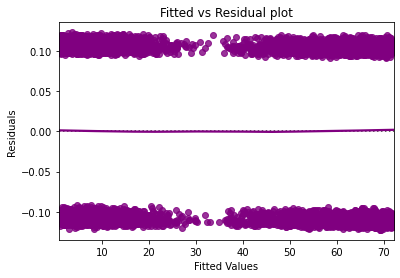

```python
# let's plot the fitted values vs residuals

sns.residplot(
    data=df_pred, x="Fitted Values", y="Residuals", color="purple", lowess=True
)
plt.xlabel("Fitted Values")
plt.ylabel("Residuals")
plt.title("Fitted vs Residual plot")
plt.show()
```

TEST FOR NORMALITY We will test for normality by checking the distribution of residuals, by checking the Q-Q plot of residuals, and by using the Shapiro-Wilk test. If the residuals follow a normal distribution, they will make a straight line plot, otherwise not. If the p-value of the Shapiro-Wilk test is greater than 0.05, we can say the residuals are normally distributed.

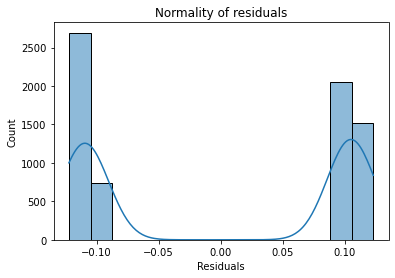

```python
sns.histplot(data=df_pred, x="Residuals", kde=True)
plt.title("Normality of residuals")
plt.show()
```

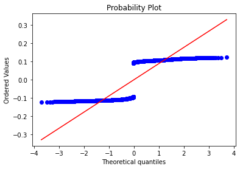

```python
import pylab
import scipy.stats as stats

stats.probplot(df_pred["Residuals"], dist="norm", plot=pylab)
plt.show()
```

```python
stats.shapiro(df_pred["Residuals"])
```

```
ShapiroResult(statistic=0.6830965280532837, pvalue=0.0)
```

```python
import statsmodels.stats.api as sms
from statsmodels.compat import lzip

name = ["F statistic", "p-value"]
test = sms.het_goldfeldquandt(df_pred["Residuals"], x_train2)
lzip(name, test)
```

```
[('F statistic', 0.999330487146247), ('p-value', 0.5078843164046024)]
```

Observations

Since p-value > 0.05, the residuals are homoscedastic. So, the assumption is satisfied.